# 01-notas

Joel Rodriguez Herrera (joelrh-lcg)

# Clase martes 23 de febrero

## Introducción a R: Creación de proyectos

Para crear proyecto:

```r
#usethis::create_project("/path/newProject")
```

Para crear archivo setup:

```r
#usethis::use_r('01-notas')
```

Configurar repositorio y vincularlo con GitHub:

```r
usethis::create_github_token()
# En la pagina web definir nombre del repo y obtener token
# Para el uso del servidor se necesita modificar arhivo publico con token
usethis::edit_r_environ()
# GITHUB_PAT=TU_CLAVE_DE_40_LETRAS
# recuerda reiniciar sesión de R
## Para inicializar el repositorio de Git
usethis::use_git()
## Para conectar tu repositorio local de Git con los servidores de GitHub
usethis::use_github()
```

## Clonar repositorios de GitHub

```r
## Opción más nueva:
library("gert")
repo <- git_clone(
    "https://github.com/lcolladotor/rnaseq_LCG-UNAM_2021",
    "~/rnaseq_LCG-UNAM_2021"
)
setwd(repo)
```

## Discusión en equipo sobre paquetes de Bioconductor

La mayoría de los paquetes son muy recientes y con descargar insuficientes para determinar todos los posibles errores que puedan surgir a la hora de usarlos. Suelen tener documentación suficiente para documentar su uso, pero podrían no cubrir situaciones no previstas. Aunque sí se ven varias opciones de contacto, encontramos uno que no tiene contacto ni forma de aclarar. Por ser tan recientes, se espera que no requieran tener tantas actualizaciones; sin embargo, encontramos paquetes donde GitHub mostraba que faltaban actualizaciones.

Todos los paquetes analizados, todos parecen funcionar en todos los sitemas operativos.

El paquete elegido fue: GWENA

En todos los demás había la posibilidad de comentar en Issues de GitHub, pero fue el único donde había errores comentados y resueltos. El autor@ contestó a los 3 días, lo cual parece muy buena atención y disposición de ayudar. Desde el Overview y documentación, con figuras y recursos gráficos se ve la dedicación que le da a que se entienda la teoría del paquete y la parte técnica de su funcionamiento.

Tiene más descargar que los demás paquetes e interacción. Además, es el más actualizado.

También cabe destacar que nos llamó la atención la idea y el propósito del paquete porque creemos de gran utilidad el análisis de toda la red de co-expresión génica dentro de un solo pipeline.

## Conclusión

Podemos utilizar la descripción de los paquetes, la atención que le brindan sus creadores en forma de actualizaciones, resoluciones de problemaso dudas, su soporte en distintos sistemas operativos, y otras indicaciones, que en general tienen que ver con el mantenimiento y atención de los programadores por la documentación de su paquete, para evaluar en primera instancia la fiabilidad de un paquete.

# Clase miercoles 24 de febrero

## SummarizedExperiment

El paquete de SummarizedExperiment está compuesto por tablas con información sobre las muestras dentro de un experimento. Es un objeto que se utiliza para el análisis de expresión diferencial. Las tablas de información están ligadas y cada una almacena información distinta.

### Tablas de información

- rowRanges: tenemos los genes, un renglon por gen y una columna por cada dato de información de cada gen.
- assay(s): podemos tener varias tablas de assay, tenemos un renglón por gen y una columna por muestra. Entonces en cada celda vamos a tener el número de veces que observamos el gen (expresión) para cada muestra.
- colData: tiene un renglón por cada muestra y una columna por cada variable de información sobre las muestras.

*Nota*: Pueden haber más tablas como de información del experimento (exptData)

## Crear objeto

```r
## DE FORMA GENERAL:

se <- SummarizedExperiment(
  assays,
  rowData,
  colData,
  exptData
)
```

Dentro del objeto SummarizedExperiment se usa el objeto GenomicRanges (GRanges) para guardar las información de los genes.

### Ejemplo

```r
library("SummarizedExperiment")
## De los ejemplos en la ayuda oficial

## Creamos los datos para nuestro objeto de tipo SummarizedExperiment
## para 200 genes a lo largo de 6 muestras
nrows <- 200
ncols <- 6

## Números al azar de cuentas
set.seed(20210223)
counts <- matrix(runif(nrows * ncols, 1, 1e4), nrows)

## Información de nuestros genes
rowRanges <- GRanges(
  rep(c("chr1", "chr2"), c(50, 150)),
  IRanges(floor(runif(200, 1e5, 1e6)), width = 100),
  strand = sample(c("+", "-"), 200, TRUE),
  feature_id = sprintf("ID%03d", 1:200)
)
names(rowRanges) <- paste0("gene_", seq_len(length(rowRanges)))

## Información de nuestras muestras
colData <- DataFrame(
  Treatment = rep(c("ChIP", "Input"), 3),
  row.names = LETTERS[1:6]
)

## Juntamos ahora toda la información en un solo objeto de R
rse <- SummarizedExperiment(
  assays = SimpleList(counts = counts),
  rowRanges = rowRanges,
  colData = colData
)

## Exploremos el objeto resultante
rse
```

```
## class: RangedSummarizedExperiment
## dim: 200 6
## metadata(0):
## assays(1): counts
## rownames(200): gene_1 gene_2 ... gene_199 gene_200
## rowData names(1): feature_id
## colnames(6): A B ... E F
## colData names(1): Treatment
```

```r
## Número de genes y muestras
dim(rse)
```

```
## [1] 200   6
```

```r
## IDs de nuestros genes y muestras
dimnames(rse)
```

```
## [[1]]
##   [1] "gene_1"   "gene_2"   "gene_3"   "gene_4"   "gene_5"   "gene_6"
##   [7] "gene_7"   "gene_8"   "gene_9"   "gene_10"  "gene_11"  "gene_12"
##  [13] "gene_13"  "gene_14"  "gene_15"  "gene_16"  "gene_17"  "gene_18"
##  [19] "gene_19"  "gene_20"  "gene_21"  "gene_22"  "gene_23"  "gene_24"
##  [25] "gene_25"  "gene_26"  "gene_27"  "gene_28"  "gene_29"  "gene_30"
##  [31] "gene_31"  "gene_32"  "gene_33"  "gene_34"  "gene_35"  "gene_36"
##  [37] "gene_37"  "gene_38"  "gene_39"  "gene_40"  "gene_41"  "gene_42"
##  [43] "gene_43"  "gene_44"  "gene_45"  "gene_46"  "gene_47"  "gene_48"
##  [49] "gene_49"  "gene_50"  "gene_51"  "gene_52"  "gene_53"  "gene_54"
##  [55] "gene_55"  "gene_56"  "gene_57"  "gene_58"  "gene_59"  "gene_60"
##  [61] "gene_61"  "gene_62"  "gene_63"  "gene_64"  "gene_65"  "gene_66"
##  [67] "gene_67"  "gene_68"  "gene_69"  "gene_70"  "gene_71"  "gene_72"
##  [73] "gene_73"  "gene_74"  "gene_75"  "gene_76"  "gene_77"  "gene_78"
##  [79] "gene_79"  "gene_80"  "gene_81"  "gene_82"  "gene_83"  "gene_84"
```

[output cut: 23 more lines]

```r
## Nombres de tablas de cuentas que tenemos (RPKM, CPM, counts, logcounts, etc)
assayNames(rse)
```

```
## [1] "counts"
```

```r
## El inicio de nuestra tabla de cuentas
head(assay(rse))
```

```
##               A        B         C         D         E        F
## gene_1 2577.960 8526.615 2226.3070 3615.8967 1723.8851 3267.954
## gene_2 7793.183 3462.579  478.2716 7688.3839  295.2813 2698.921
## gene_3 9571.769 5280.564 9772.1671 9916.0076 2621.2085 6880.067
## gene_4 4641.969 2784.091 6670.6757  258.5218 2771.8970 8737.586
## gene_5 6436.758 7053.276 9978.8199 3588.1194 1447.9821 7290.890
## gene_6 6845.704 1502.045 4383.5686 9750.8286 3529.3153 2192.060
```

```r
## Información de los genes en un objeto de Bioconductor
rowRanges(rse)
```

```
## GRanges object with 200 ranges and 1 metadata column:
##            seqnames        ranges strand |  feature_id
##               <Rle>     <IRanges>  <Rle> | <character>
##     gene_1     chr1 286235-286334      + |       ID001
##     gene_2     chr1 586770-586869      - |       ID002
##     gene_3     chr1 577897-577996      + |       ID003
##     gene_4     chr1 494350-494449      + |       ID004
##     gene_5     chr1 686692-686791      - |       ID005
##        ...      ...           ...    ... .         ...
##   gene_196     chr2 804998-805097      - |       ID196
##   gene_197     chr2 177462-177561      - |       ID197
##   gene_198     chr2 649993-650092      - |       ID198
##   gene_199     chr2 275940-276039      - |       ID199
##   gene_200     chr2 487418-487517      + |       ID200
##   -------
##   seqinfo: 2 sequences from an unspecified genome; no seqlengths
```

```r
## Ver los "unique" levels (cromosomas)
seqlevels(rse)
```

```
## [1] "chr1" "chr2"
```

```r
## Tabla comprimida por repetición de cada level (chromosoma)
seqnames(rowRanges(rse))
```

```
## factor-Rle of length 200 with 2 runs
##   Lengths:   50  150
##   Values : chr1 chr2
## Levels(2): chr1 chr2
```

```r
## Tabla con información de los genes
rowData(rse) # es idéntico a 'mcols(rowRanges(rse))'
```

```
## DataFrame with 200 rows and 1 column
##           feature_id
##          <character>
## gene_1         ID001
## gene_2         ID002
## gene_3         ID003
## gene_4         ID004
## gene_5         ID005
## ...              ...
## gene_196       ID196
## gene_197       ID197
## gene_198       ID198
## gene_199       ID199
## gene_200       ID200
```

```r
## Tabla con información de las muestras
colData(rse)
```

```
## DataFrame with 6 rows and 1 column
##     Treatment
##   <character>
## A        ChIP
## B       Input
## C        ChIP
## D       Input
## E        ChIP
## F       Input
```

*Nota:*

- colNames: muestra los nombres de las muestras.
- colData: variables de información de las muestras.

```r
## Ver los "unique" levels (cromosomas)
seqlevels(rse)
```

```
## [1] "chr1" "chr2"
```

```r
## Tabla comprimida por repetición de cada level (chromosoma)
seqnames(rowRanges(rse))
```

```
## factor-Rle of length 200 with 2 runs
##   Lengths:   50  150
##   Values : chr1 chr2
## Levels(2): chr1 chr2
```

### Ejercicio

Explica que sucede en las siguientes líneas de código de R.

```r
## Comando 1
rse[1:2, ]
```

```
## class: RangedSummarizedExperiment
## dim: 2 6
## metadata(0):
## assays(1): counts
## rownames(2): gene_1 gene_2
## rowData names(1): feature_id
## colnames(6): A B ... E F
## colData names(1): Treatment
```

```r
head(assay(rse[1:2, ]))
```

```
##               A        B         C        D         E        F
## gene_1 2577.960 8526.615 2226.3070 3615.897 1723.8851 3267.954
## gene_2 7793.183 3462.579  478.2716 7688.384  295.2813 2698.921
```

*Explicación:* Solo se muestran los primeros 2 genes, para esto se accesa a la tabla de rowData y a las tablas de assays para asegurarse de solo mostrar los renglones correspondientes

```r
## Comando 2
rse[, c("A", "D", "F")]
```

```
## class: RangedSummarizedExperiment
## dim: 200 3
## metadata(0):
## assays(1): counts
## rownames(200): gene_1 gene_2 ... gene_199 gene_200
## rowData names(1): feature_id
## colnames(3): A D F
## colData names(1): Treatment
```

```r
head(assay(rse[, c("A", "D", "F")]))
```

```
##               A         D        F
## gene_1 2577.960 3615.8967 3267.954
## gene_2 7793.183 7688.3839 2698.921
## gene_3 9571.769 9916.0076 6880.067
## gene_4 4641.969  258.5218 8737.586
## gene_5 6436.758 3588.1194 7290.890
## gene_6 6845.704 9750.8286 2192.060
```

```r
#tras bambalinas
which(colnames(rse)%in%c("A", "D", "F"))
```

```
## [1] 1 4 6
```

## ISEE: interactivo

Para visualizar objetos SummarizedExperiment.

```r
## Explora el objeto rse de forma interactiva
library("iSEE")
#iSEE::iSEE(rse)
```

```r
## Descarguemos unos datos de spatialLIBD
sce_layer <- spatialLIBD::fetch_data("sce_layer")
```

```
## snapshotDate(): 2020-10-27
```

```
## 2021-03-01 04:23:54 loading file ~/.cache/BiocFileCache/34d9727d87d9a_Human_DLPFC_Visium_processedData_sce_scran_sce_layer_spatialLIBD.Rdata%3Fdl%3D1
```

```r
#iSEE::iSEE(sce_layer)
```

### Ejercicio

Descarga un PDF que reproduzca la imagen del lado derecho de la siguiente diapositiva. Incluye ese PDF en tu repositorio de notas del curso.

```r
## Los archivos correspondientes al ejercicio se encuentran en la carpeta EJERCICIOS:

#### ReducedDimensionPlot1.pdf
#### ComplexHeatmapPlot1.pdf
```

## Recount

Se usa para procesar datos crudos (FASTQ). Podemos descargar datos de experimentos y obtener un objeto SummarizedExperiment.

En recount3 se tienen datos de miles de estudios en humanos y en ratón.

```r
# Cuando impotamos la libreria tambien se importa SummarizedExperiment
library("recount3")
```

```r
## Revisemos todos los proyectos con datos de humano en recount3
human_projects <- available_projects()
```

```
## 2021-03-01 04:24:02 caching file sra.recount_project.MD.gz.
```

```
## 2021-03-01 04:24:03 caching file gtex.recount_project.MD.gz.
```

```
## 2021-03-01 04:24:05 caching file tcga.recount_project.MD.gz.
```

Podemos ver el data frame con todos los estudios de humano disponibles en recount3.

```r
human_projects
```

| project | organism | file_source | project_home | project_type | n_samples |
| --- | --- | --- | --- | --- | --- |
| SRP107565 | human | sra | data_sources/sra | data_sources | 216 |
| SRP149665 | human | sra | data_sources/sra | data_sources | 4 |
| SRP017465 | human | sra | data_sources/sra | data_sources | 23 |
| SRP119165 | human | sra | data_sources/sra | data_sources | 6 |
| SRP133965 | human | sra | data_sources/sra | data_sources | 12 |
| SRP096765 | human | sra | data_sources/sra | data_sources | 7 |
| SRP124965 | human | sra | data_sources/sra | data_sources | 12 |
| SRP189165 | human | sra | data_sources/sra | data_sources | 15 |
| SRP050365 | human | sra | data_sources/sra | data_sources | 10 |
| SRP123065 | human | sra | data_sources/sra | data_sources | 41 |

[output cut: 8732 more lines]

```r
## Encuentra tu proyecto de interés. Aquí usaremos
## SRP009615 de ejemplo

proj_info <- subset(
    human_projects,
    project == "SRP009615" & project_type == "data_sources"
)
```

```r
# Crea un objetio de tipo RangedSummarizedExperiment (RSE)
## con la información a nivel de genes
rse_gene_SRP009615 <- create_rse(proj_info)
```

```
## 2021-03-01 04:24:14 downloading and reading the metadata.
```

```
## 2021-03-01 04:24:16 caching file sra.sra.SRP009615.MD.gz.
```

```
## 2021-03-01 04:24:18 caching file sra.recount_project.SRP009615.MD.gz.
```

```
## 2021-03-01 04:24:19 caching file sra.recount_qc.SRP009615.MD.gz.
```

```
## 2021-03-01 04:24:21 caching file sra.recount_seq_qc.SRP009615.MD.gz.
```

```
## 2021-03-01 04:24:22 caching file sra.recount_pred.SRP009615.MD.gz.
```

```
## 2021-03-01 04:24:24 downloading and reading the feature information.
```

```
## 2021-03-01 04:24:25 caching file human.gene_sums.G026.gtf.gz.
```

```
## 2021-03-01 04:24:26 downloading and reading the counts: 12 samples across 63856 features.
```

```
## 2021-03-01 04:24:28 caching file sra.gene_sums.SRP009615.G026.gz.
```

```
## 2021-03-01 04:24:29 construcing the RangedSummarizedExperiment (rse) object.
```

```r
rse_gene_SRP009615
```

```
## class: RangedSummarizedExperiment
## dim: 63856 12
## metadata(8): time_created recount3_version ... annotation recount3_url
## assays(1): raw_counts
## rownames(63856): ENSG00000278704.1 ENSG00000277400.1 ...
##   ENSG00000182484.15_PAR_Y ENSG00000227159.8_PAR_Y
## rowData names(10): source type ... havana_gene tag
## colnames(12): SRR387777 SRR387778 ... SRR389077 SRR389078
## colData names(175): rail_id external_id ...
##   recount_pred.curated.cell_line BigWigURL
```

Si nos fijamos en assays tenemos raw_counts porque son las cuentas de las bases sobrelapantes en todos los segmentos exónicos, no es el número de lecturas sobrelapantes, si no la suma de las bases. Hay transformaciones para pasar de esa cuenta a número de lecturas sobrelapantes, que son más comunes.

```r
## Transformación de cuentas a lecturas sobrelapantes
assay(rse_gene_SRP009615, "counts") <- compute_read_counts(rse_gene_SRP009615)
rse_gene_SRP009615
```

```
## class: RangedSummarizedExperiment
## dim: 63856 12
## metadata(8): time_created recount3_version ... annotation recount3_url
## assays(2): raw_counts counts
## rownames(63856): ENSG00000278704.1 ENSG00000277400.1 ...
##   ENSG00000182484.15_PAR_Y ENSG00000227159.8_PAR_Y
## rowData names(10): source type ... havana_gene tag
## colnames(12): SRR387777 SRR387778 ... SRR389077 SRR389078
## colData names(175): rail_id external_id ...
##   recount_pred.curated.cell_line BigWigURL
```

```r
rse_gene_SRP009615 <- expand_sra_attributes(rse_gene_SRP009615)
colData(rse_gene_SRP009615)[
    ,
    grepl("^sra_attribute", colnames(colData(rse_gene_SRP009615)))
]
```

```
## DataFrame with 12 rows and 4 columns
##           sra_attribute.cells sra_attribute.shRNA_expression
##                   <character>                    <character>
## SRR387777                K562                             no
## SRR387778                K562             yes, targeting SRF
## SRR387779                K562                             no
## SRR387780                K562              yes targeting SRF
## SRR389079                K562            no shRNA expression
## ...                       ...                            ...
## SRR389082                K562         expressing shRNA tar..
## SRR389083                K562            no shRNA expression
## SRR389084                K562         expressing shRNA tar..
## SRR389077                K562            no shRNA expression
## SRR389078                K562         expressing shRNA tar..
##           sra_attribute.source_name sra_attribute.treatment
##                         <character>             <character>
## SRR387777                    SL2933               Puromycin
## SRR387778                    SL2934  Puromycin, doxycycline
## SRR387779                    SL5265               Puromycin
## SRR387780                    SL3141  Puromycin, doxycycline
## SRR389079                    SL6485               Puromycin
## ...                             ...                     ...
## SRR389082                    SL2592  Puromycin, doxycycline
## SRR389083                    SL4337               Puromycin
## SRR389084                    SL4326  Puromycin, doxycycline
## SRR389077                    SL1584               Puromycin
## SRR389078                    SL1583  Puromycin, doxycycline
```

## Ejercicio

Reproducir gráfica

```r
#iSEE::iSEE(rse_gene_SRP009615)
```

```r
## RESULTADO:

### Se ecnuenta en la carpeta EJERCICIOS con el nombre FeatureAssayPlot1.pdf
```

# Clase jueves 25 de febrero

## Análisis de coeficientes

Funcion model.matrix es usada por muchas otras funciones para el calculo de coeficientes. Se usa el signo ‘+’ para decir qu etenemos más de una variable explicativa relacionada a nuestra variable y. El signo ’*’ se usa para decir que las variables explicativas dependientes (x) están relacionadas, y esa relación (ambas variables en conjunto) explican a (y). La tilde (~) es para definir la variable a explicar y separarla de las explicativas

$y~x_1+x_2+x_3*x_4$

### Ejemplo 1

```r
## Datos de ejemplo
(sampleData <- data.frame(
    genotype = rep(c("A", "B"), each = 4),
    treatment = rep(c("ctrl", "trt"), 4)
))
```

| genotype | treatment |
| --- | --- |
| A | ctrl |
| A | trt |
| A | ctrl |
| A | trt |
| B | ctrl |
| B | trt |
| B | ctrl |
| B | trt |

```r
## Creemos las imágenes usando ExploreModelMatrix
vd <- ExploreModelMatrix::VisualizeDesign(
    sampleData = sampleData,
    designFormula = ~ genotype + treatment,
    textSizeFitted = 4
)
```

```r
vd
```

```
## $sampledata
##   genotype treatment                                  value nSamples
## 1        A      ctrl                            (Intercept)        2
## 2        A       trt             (Intercept) + treatmenttrt        2
## 3        B      ctrl                (Intercept) + genotypeB        2
## 4        B       trt (Intercept) + genotypeB + treatmenttrt        2
##
## $plotlist
## $plotlist[[1]]
```

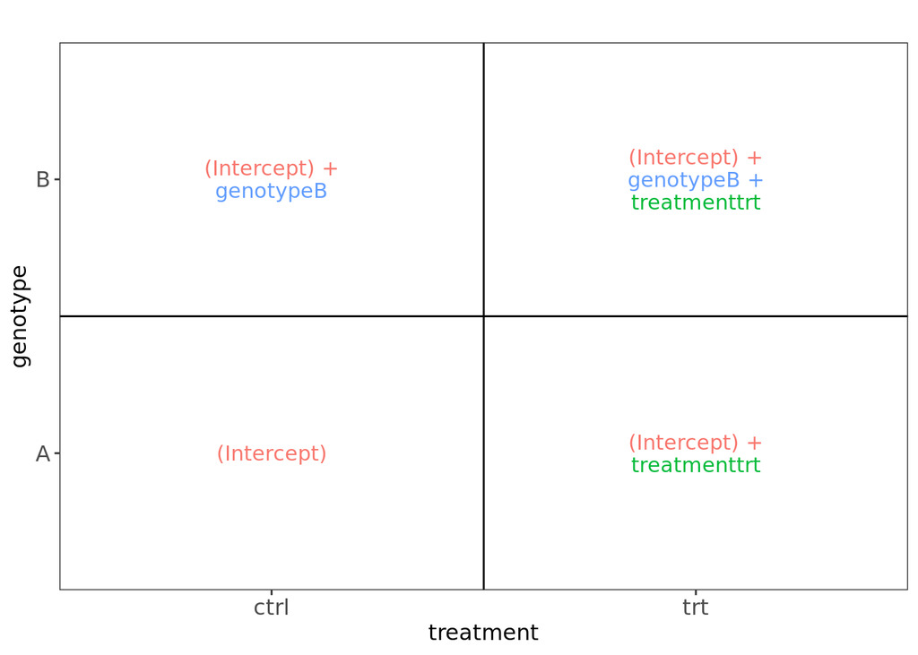

```
##
##
## $designmatrix
##   (Intercept) genotypeB treatmenttrt
## 1           1         0            0
## 2           1         0            1
## 3           1         0            0
## 4           1         0            1
## 5           1         1            0
## 6           1         1            1
## 7           1         1            0
## 8           1         1            1
##
## $pseudoinverse
##                   1      2      3      4      5      6      7      8
## (Intercept)   0.375  0.125  0.375  0.125  0.125 -0.125  0.125 -0.125
## genotypeB    -0.250 -0.250 -0.250 -0.250  0.250  0.250  0.250  0.250
## treatmenttrt -0.250  0.250 -0.250  0.250 -0.250  0.250 -0.250  0.250
##
## $vifs
##    coefficient vif
## 1    genotypeB   1
## 2 treatmenttrt   1
##
## $colors
##  (Intercept) treatmenttrt    genotypeB
##    "#F8766D"    "#00BA38"    "#619CFF"
##
## $cooccurrenceplots
## $cooccurrenceplots[[1]]
```

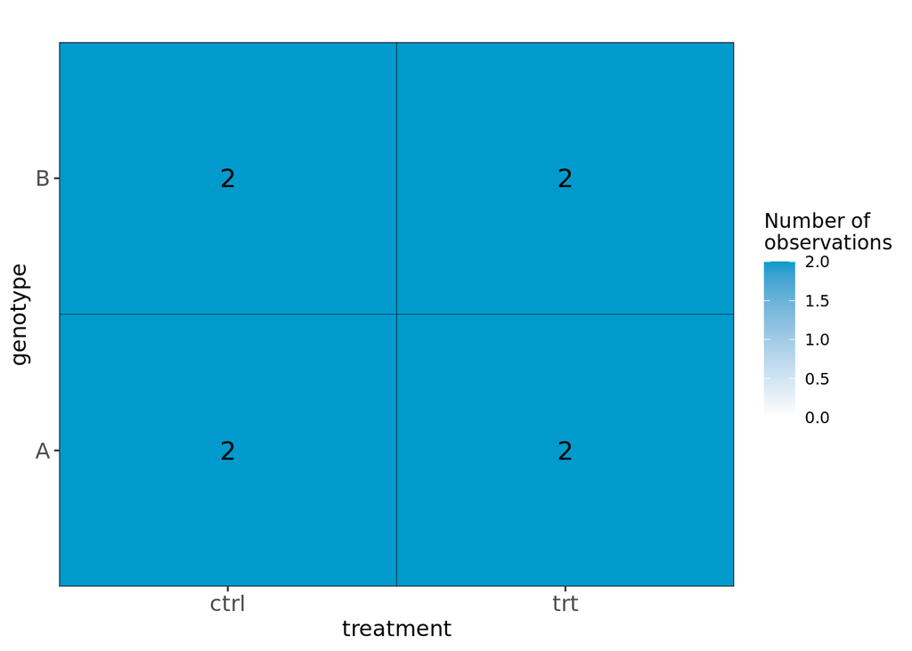

```
##
##
## $totnbrrows
## [1] 2
```

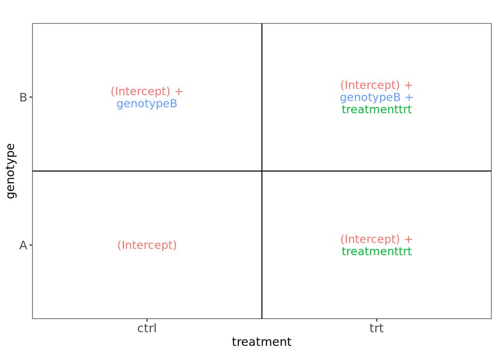

```r
## Veamos las imágenes
cowplot::plot_grid(plotlist = vd$plotlist)
```

```r
library(ExploreModelMatrix)

app <- ExploreModelMatrix(
    sampleData = sampleData,
    designFormula = ~ genotype + treatment
)
if (interactive()) shiny::runApp(app)
```

### Ejemplo 2

```r
(sampleData <- data.frame(
  Response = rep(c("Resistant", "Sensitive"), c(12, 18)),
  Patient = factor(rep(c(1:6, 8, 11:18), each = 2)),
  Treatment = factor(rep(c("pre","post"), 15)),
  ind.n = factor(rep(c(1:6, 2, 5:12), each = 2))))
```

| Response | Patient | Treatment | ind.n |
| --- | --- | --- | --- |
| Resistant | 1 | pre | 1 |
| Resistant | 1 | post | 1 |
| Resistant | 2 | pre | 2 |
| Resistant | 2 | post | 2 |
| Resistant | 3 | pre | 3 |
| Resistant | 3 | post | 3 |
| Resistant | 4 | pre | 4 |
| Resistant | 4 | post | 4 |
| Resistant | 5 | pre | 5 |
| Resistant | 5 | post | 5 |

[output cut: 20 more lines]

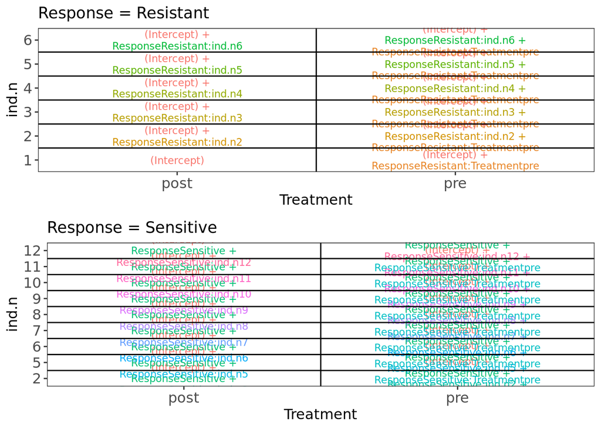

```r
vd <- VisualizeDesign(
  sampleData = sampleData,
  designFormula = ~ Response + Response:ind.n + Response:Treatment,
  textSizeFitted = 3
)
cowplot::plot_grid(plotlist = vd$plotlist, ncol = 1)
```

```r
app <- ExploreModelMatrix(
  sampleData = sampleData,
  designFormula = ~ Response + Response:ind.n + Response:Treatment
)
if (interactive()) shiny::runApp(app)
```

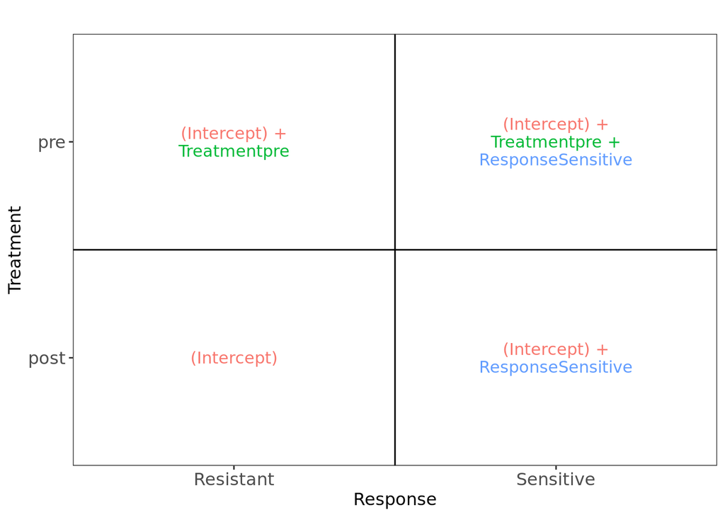

```r
vd <- VisualizeDesign(sampleData = sampleData,
                      designFormula = ~ Treatment + Response,
                      textSizeFitted = 4)
cowplot::plot_grid(plotlist = vd$plotlist, ncol = 1)
```

### Ejemplo 3

Debemos de eliminar las variables linealmente dependientes.

```r
(sampleData = data.frame(
  condition = factor(rep(c("ctrl_minus", "ctrl_plus",
                           "ko_minus", "ko_plus"), 3)),
  batch = factor(rep(1:6, each = 2))))
```

| condition | batch |
| --- | --- |
| ctrl_minus | 1 |
| ctrl_plus | 1 |
| ko_minus | 2 |
| ko_plus | 2 |
| ctrl_minus | 3 |
| ctrl_plus | 3 |
| ko_minus | 4 |
| ko_plus | 4 |
| ctrl_minus | 5 |
| ctrl_plus | 5 |

[output cut: 2 more lines]

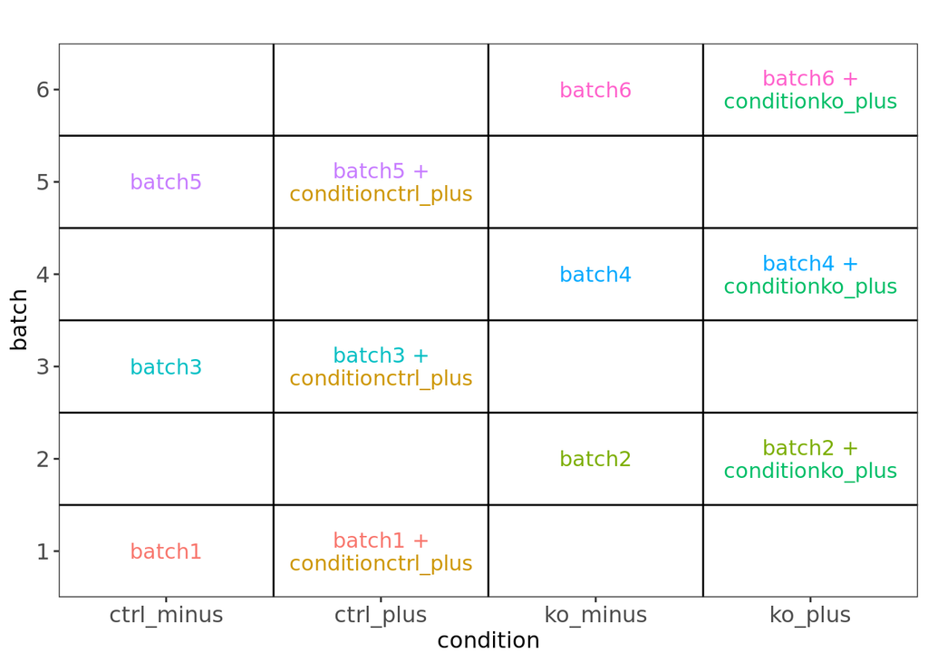

```r
## Aqui es cuando eliminamos la columna linealmente dependiente
### Se agrega 0 al principio de la formula para eliminar el intercepto, porque queremos tener un coeficiente para cada batch
vd <- VisualizeDesign(sampleData = sampleData,
                      designFormula = ~ 0 + batch + condition,
                      textSizeFitted = 4, lineWidthFitted = 20,
                      dropCols = "conditionko_minus")
cowplot::plot_grid(plotlist = vd$plotlist, ncol = 1)
```

## Datos de SRP045638 usando recount3

```r
human_projects <- available_projects()
```

```
## 2021-03-01 04:24:36 caching file sra.recount_project.MD.gz.
```

```
## 2021-03-01 04:24:38 caching file gtex.recount_project.MD.gz.
```

```
## 2021-03-01 04:24:39 caching file tcga.recount_project.MD.gz.
```

```r
rse_gene_SRP045638 <- create_rse(
    subset(
        human_projects,
        project == "SRP045638" & project_type == "data_sources"
    )
)
```

```
## 2021-03-01 04:24:46 downloading and reading the metadata.
```

```
## 2021-03-01 04:24:48 caching file sra.sra.SRP045638.MD.gz.
```

```
## 2021-03-01 04:24:50 caching file sra.recount_project.SRP045638.MD.gz.
```

```
## 2021-03-01 04:24:51 caching file sra.recount_qc.SRP045638.MD.gz.
```

```
## 2021-03-01 04:24:53 caching file sra.recount_seq_qc.SRP045638.MD.gz.
```

```
## 2021-03-01 04:24:54 caching file sra.recount_pred.SRP045638.MD.gz.
```

```
## 2021-03-01 04:24:56 downloading and reading the feature information.
```

```
## 2021-03-01 04:24:57 caching file human.gene_sums.G026.gtf.gz.
```

```
## 2021-03-01 04:24:59 downloading and reading the counts: 66 samples across 63856 features.
```

```
## 2021-03-01 04:25:00 caching file sra.gene_sums.SRP045638.G026.gz.
```

```
## 2021-03-01 04:25:02 construcing the RangedSummarizedExperiment (rse) object.
```

```r
assay(rse_gene_SRP045638, "counts") <- compute_read_counts(rse_gene_SRP045638)
```

```r
rse_gene_SRP045638$sra.sample_attributes[1:3]
```

```
## [1] "age;;67.78|biomaterial_provider;;LIBD|BioSampleModel;;Human|dev_stage;;Fetal|disease;;Control|Fraction;;total|isolate;;DLPFC|race;;AA|RIN;;8.3|sex;;female|tissue;;DLPFC"
## [2] "age;;40.42|biomaterial_provider;;LIBD|BioSampleModel;;Human|disease;;Control|Fraction;;total|isolate;;DLPFC|race;;AA|RIN;;8.4|sex;;male|tissue;;DLPFC"
## [3] "age;;41.58|biomaterial_provider;;LIBD|BioSampleModel;;Human|disease;;control|Fraction;;total|isolate;;R2869|race;;AA|RIN;;8.7|sex;;male|tissue;;DLPFC"
```

Hay que eliminar la característica dev_stage;;Fetal que solo está en la primera muestra.

```r
rse_gene_SRP045638$sra.sample_attributes <- gsub("dev_stage;;Fetal\\|", "", rse_gene_SRP045638$sra.sample_attributes)
rse_gene_SRP045638$sra.sample_attributes[1:3]
```

```
## [1] "age;;67.78|biomaterial_provider;;LIBD|BioSampleModel;;Human|disease;;Control|Fraction;;total|isolate;;DLPFC|race;;AA|RIN;;8.3|sex;;female|tissue;;DLPFC"
## [2] "age;;40.42|biomaterial_provider;;LIBD|BioSampleModel;;Human|disease;;Control|Fraction;;total|isolate;;DLPFC|race;;AA|RIN;;8.4|sex;;male|tissue;;DLPFC"
## [3] "age;;41.58|biomaterial_provider;;LIBD|BioSampleModel;;Human|disease;;control|Fraction;;total|isolate;;R2869|race;;AA|RIN;;8.7|sex;;male|tissue;;DLPFC"
```

```r
rse_gene_SRP045638 <- expand_sra_attributes(rse_gene_SRP045638)

colData(rse_gene_SRP045638)[
    ,
    grepl("^sra_attribute", colnames(colData(rse_gene_SRP045638)))
]
```

```
## DataFrame with 66 rows and 10 columns
##            sra_attribute.age sra_attribute.biomaterial_provider
##                  <character>                        <character>
## SRR2071341             67.78                               LIBD
## SRR2071345             40.42                               LIBD
## SRR2071346             41.58                               LIBD
## SRR2071347             44.17                               LIBD
## SRR2071348           -0.3836                               LIBD
## ...                      ...                                ...
## SRR2071366             66.72                               LIBD
## SRR2071372             43.88                               LIBD
## SRR2071373             15.17                               LIBD
## SRR2071374             70.95                               LIBD
## SRR2071375              4.14                               LIBD
##            sra_attribute.BioSampleModel sra_attribute.disease
##                             <character>           <character>
## SRR2071341                        Human               Control
## SRR2071345                        Human               Control
## SRR2071346                        Human               control
## SRR2071347                        Human               control
## SRR2071348                        Human               control
## ...                                 ...                   ...
## SRR2071366                        Human               control
## SRR2071372                        Human               control
## SRR2071373                        Human               control
## SRR2071374                        Human               control
## SRR2071375                        Human               control
##            sra_attribute.Fraction sra_attribute.isolate sra_attribute.race
##                       <character>           <character>        <character>
## SRR2071341                  total                 DLPFC                 AA
## SRR2071345                  total                 DLPFC                 AA
## SRR2071346                  total                 R2869                 AA
## SRR2071347                  total                 R3098                 AA
## SRR2071348                  total                 R3452                 AA
## ...                           ...                   ...                ...
## SRR2071366                  total                 R3763               CAUC
## SRR2071372                  total                 R4166                 AA
## SRR2071373                  total                 R4196               CAUC
## SRR2071374                  total                 R4338                 AS
## SRR2071375                  total                 R4699               CAUC
##            sra_attribute.RIN sra_attribute.sex sra_attribute.tissue
##                  <character>       <character>          <character>
## SRR2071341               8.3            female                DLPFC
## SRR2071345               8.4              male                DLPFC
## SRR2071346               8.7              male                DLPFC
## SRR2071347               5.3            female                DLPFC
## SRR2071348               9.6            female                DLPFC
## ...                      ...               ...                  ...
## SRR2071366                 7            female                DLPFC
## SRR2071372               8.7              male                DLPFC
## SRR2071373               7.9            female                DLPFC
## SRR2071374               8.3              male                DLPFC
## SRR2071375               8.7              male                DLPFC
```

Tenemos un problema porque las columnas numéricas son caracteres, hay que hacer casting:

```r
## Pasar de character a nuemric o factor
rse_gene_SRP045638$sra_attribute.age <- as.numeric(rse_gene_SRP045638$sra_attribute.age)
rse_gene_SRP045638$sra_attribute.disease <- factor(rse_gene_SRP045638$sra_attribute.disease)
rse_gene_SRP045638$sra_attribute.RIN <- as.numeric(rse_gene_SRP045638$sra_attribute.RIN)
rse_gene_SRP045638$sra_attribute.sex <- factor(rse_gene_SRP045638$sra_attribute.sex)

## Resumen de las variables de interés
summary(as.data.frame(colData(rse_gene_SRP045638)[
    ,
    grepl("^sra_attribute.[age|disease|RIN|sex]", colnames(colData(rse_gene_SRP045638)))
]))
```

```
##  sra_attribute.age sra_attribute.disease sra_attribute.isolate
##  Min.   :-0.4986   control:62            Length:66
##  1st Qu.: 0.3424   Control: 4            Class :character
##  Median :14.9000                         Mode  :character
##  Mean   :22.6286
##  3rd Qu.:41.2900
##  Max.   :73.9100
##  sra_attribute.RIN sra_attribute.sex
##  Min.   :5.30      female:22
##  1st Qu.:8.00      male  :44
##  Median :8.30
##  Mean   :8.15
##  3rd Qu.:8.70
##  Max.   :9.60
```

```r
## Encontraremos diferencias entre muestra prenatalas vs postnatales
rse_gene_SRP045638$prenatal <- factor(ifelse(rse_gene_SRP045638$sra_attribute.age < 0, "prenatal", "postnatal"))
table(rse_gene_SRP045638$prenatal)
```

```
##
## postnatal  prenatal
##        56        10
```

Otro analisis:

```r
## http://research.libd.org/recount3-docs/docs/quality-check-fields.html
rse_gene_SRP045638$assigned_gene_prop <- rse_gene_SRP045638$recount_qc.gene_fc_count_all.assigned / rse_gene_SRP045638$recount_qc.gene_fc_count_all.total
summary(rse_gene_SRP045638$assigned_gene_prop)
```

```
##    Min. 1st Qu.  Median    Mean 3rd Qu.    Max.
##  0.1942  0.7004  0.7591  0.7170  0.7991  0.8493
```

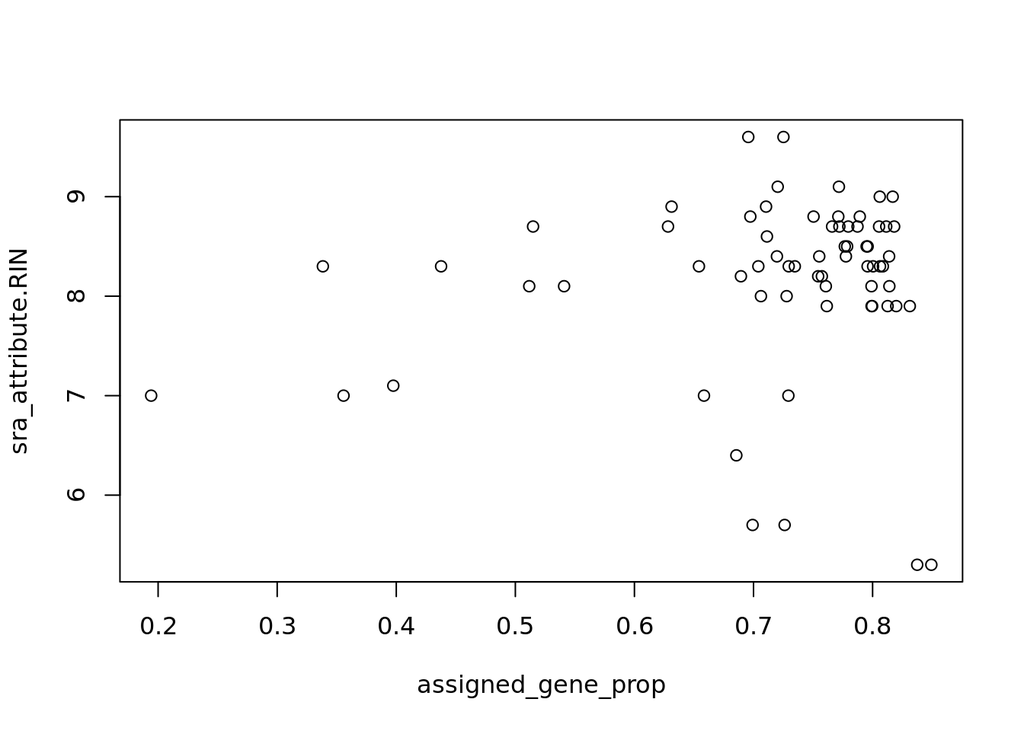

```r
with(colData(rse_gene_SRP045638), plot(assigned_gene_prop, sra_attribute.RIN))
```

```r
## Hm... veamos si hay una diferencia entre los grupos
with(colData(rse_gene_SRP045638), tapply(assigned_gene_prop, prenatal, summary))
```

```
## $postnatal
##    Min. 1st Qu.  Median    Mean 3rd Qu.    Max.
##  0.1942  0.7072  0.7719  0.7179  0.8017  0.8493
##
## $prenatal
##    Min. 1st Qu.  Median    Mean 3rd Qu.    Max.
##  0.6856  0.7004  0.7088  0.7116  0.7259  0.7347
```

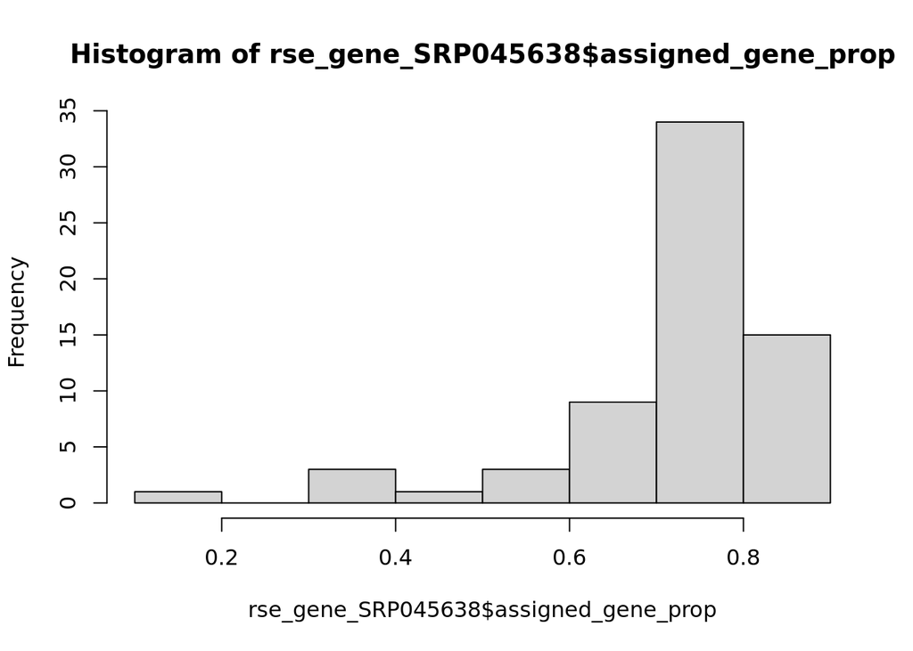

```r
## Guardemos nuestro objeto entero por si luego cambiamos de opinión
rse_gene_SRP045638_unfiltered <- rse_gene_SRP045638

## Eliminemos a muestras malas
hist(rse_gene_SRP045638$assigned_gene_prop)
```

Siempre se elmininan primero muestras y luego genes, porque para los genes usamos medias de expresión, y esta puede variar con el numero de muestras:

```r
rse_gene_SRP045638 <- rse_gene_SRP045638[, rse_gene_SRP045638$assigned_gene_prop > 0.3]

## Calculemos los niveles medios de expresión de los genes en nuestras
## muestras.
## Ojo: en un análisis real probablemente haríamos esto con los RPKMs o CPMs
## en vez de las cuentas.
gene_means <- rowMeans(assay(rse_gene_SRP045638, "counts"))
summary(gene_means)
```

```
##      Min.   1st Qu.    Median      Mean   3rd Qu.      Max.
##       0.0       0.1       2.5     817.5     171.2 1362047.9
```

```r
## Eliminamos genes
rse_gene_SRP045638 <- rse_gene_SRP045638[gene_means > 0.1, ]

## Dimensiones finales
dim(rse_gene_SRP045638)
```

```
## [1] 46932    65
```

```r
## Porcentaje de genes que retuvimos
round(nrow(rse_gene_SRP045638) / nrow(rse_gene_SRP045638_unfiltered) * 100, 2)
```

```
## [1] 73.5
```

## Normalización de datos

Antes se comparaba la expresión tan solo con el tamaño de libreria, pero hay casos en los que se podía detectar errores de comparación de expresión, como que un gen tuviera el doble de expresión que otro aún cuando tenían la misma expresión pero tenían distinto tamaño de libreria.

```r
library("edgeR") # BiocManager::install("edgeR", update = FALSE)
dge <- DGEList(
    counts = assay(rse_gene_SRP045638, "counts"),
    genes = rowData(rse_gene_SRP045638)
)
dge <- calcNormFactors(dge)
```

## Expresión dierencial

Exploramos los datos:

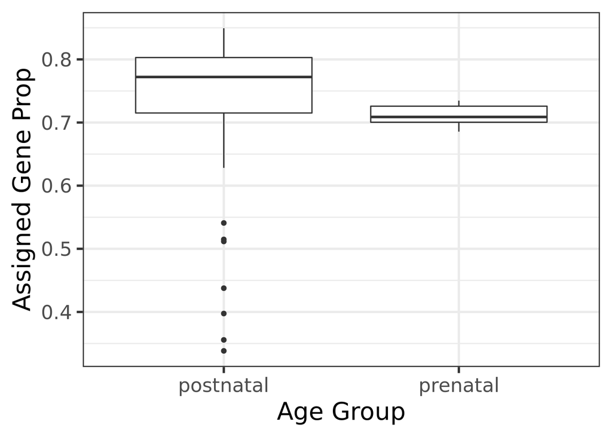

```r
library("ggplot2")
ggplot(as.data.frame(colData(rse_gene_SRP045638)), aes(y = assigned_gene_prop, x = prenatal)) +
    geom_boxplot() +
    theme_bw(base_size = 20) +
    ylab("Assigned Gene Prop") +
    xlab("Age Group")
```

```r
mod <- model.matrix(~ prenatal + sra_attribute.RIN + sra_attribute.sex + assigned_gene_prop,
    data = colData(rse_gene_SRP045638)
)
colnames(mod)
```

```
## [1] "(Intercept)"           "prenatalprenatal"      "sra_attribute.RIN"
## [4] "sra_attribute.sexmale" "assigned_gene_prop"
```

es prenatalprenatal porque la referencia es postnatal y es sexmale porque la referencia es female.

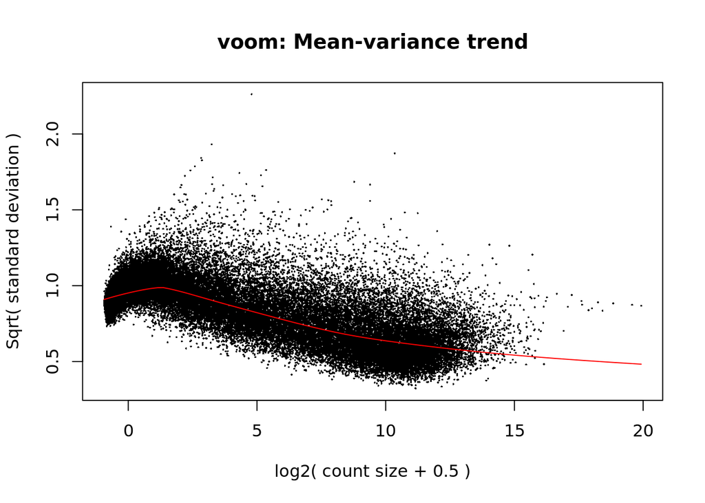

```r
library("limma")
vGene <- voom(dge, mod, plot = TRUE)
```

Usamos la version de lima de lm:

```r
# usamos eBayes para tener los valores P
eb_results <- eBayes(lmFit(vGene))

de_results <- topTable(
    eb_results,
    # usamos el coef 2 porque nos interesa analizar prenatalprenatal
    coef = 2,
    number = nrow(rse_gene_SRP045638),
    sort.by = "none"
)
dim(de_results)
```

```
## [1] 46932    16
```

```r
head(de_results)
```

|  | source | type | score | phase | gene_id | gene_type | gene_name | level | havana_gene | tag | logFC | AveExpr | t | P.Value | adj.P.Val | B |
| --- | --- | --- | --- | --- | --- | --- | --- | --- | --- | --- | --- | --- | --- | --- | --- | --- |
| ENSG00000223972.5 | HAVANA | gene | 1735 | NA | ENSG00000223972.5 | transcribed_unprocessed_pseudogene | DDX11L1 | 2 | OTTHUMG00000000961.2 | NA | -0.4464473 | -3.4480071 | -1.616387 | 1.108073e-01 | 1.399351e-01 | -5.5871402 |
| ENSG00000278267.1 | ENSEMBL | gene | 68 | NA | ENSG00000278267.1 | miRNA | MIR6859-1 | 3 | NA | NA | 1.1238124 | -1.3154875 | 6.175776 | 4.669176e-08 | 1.730504e-07 | 7.9671608 |
| ENSG00000227232.5 | HAVANA | gene | 1351 | NA | ENSG00000227232.5 | unprocessed_pseudogene | WASH7P | 2 | OTTHUMG00000000958.1 | NA | 0.6932616 | 3.6372886 | 5.723387 | 2.807302e-07 | 9.348513e-07 | 5.8016259 |
| ENSG00000284332.1 | ENSEMBL | gene | 138 | NA | ENSG00000284332.1 | miRNA | MIR1302-2 | 3 | NA | NA | 0.4646765 | -5.7349490 | 1.467797 | 1.469350e-01 | 1.811388e-01 | -5.7535500 |
| ENSG00000243485.5 | HAVANA | gene | 1021 | NA | ENSG00000243485.5 | lincRNA | MIR1302-2HG | 2 | OTTHUMG00000000959.2 | ncRNA_host | 0.9705984 | -0.6684675 | 5.110633 | 2.985939e-06 | 8.551661e-06 | 3.8413461 |
| ENSG00000237613.2 | HAVANA | gene | 1219 | NA | ENSG00000237613.2 | lincRNA | FAM138A | 2 | OTTHUMG00000000960.1 | NA | -1.5393441 | -5.3057586 | -4.169751 | 9.126976e-05 | 1.967694e-04 | 0.8591194 |

```r
## Genes diferencialmente expresados entre pre y post natal con FDR < 5%
table(de_results$adj.P.Val < 0.05)
```

```
##
## FALSE  TRUE
## 12898 34034
```

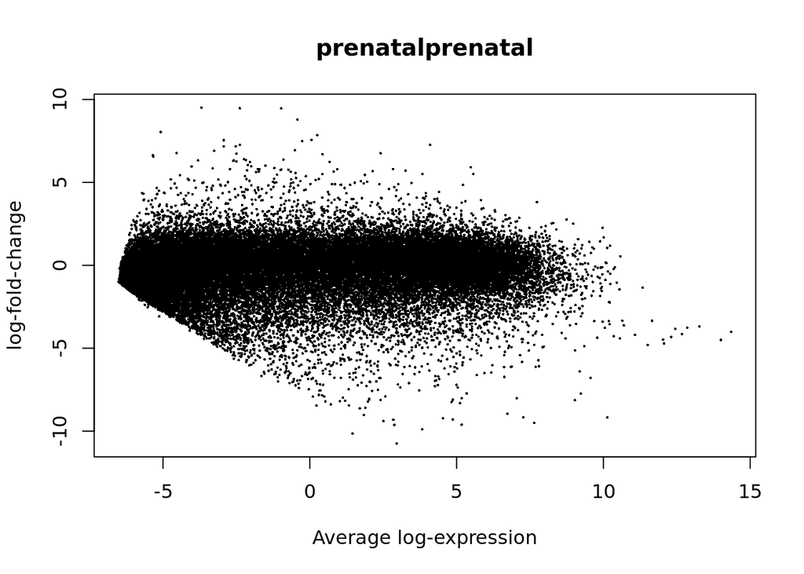

```r
## Visualicemos los resultados estadísticos
plotMA(eb_results, coef = 2)
```

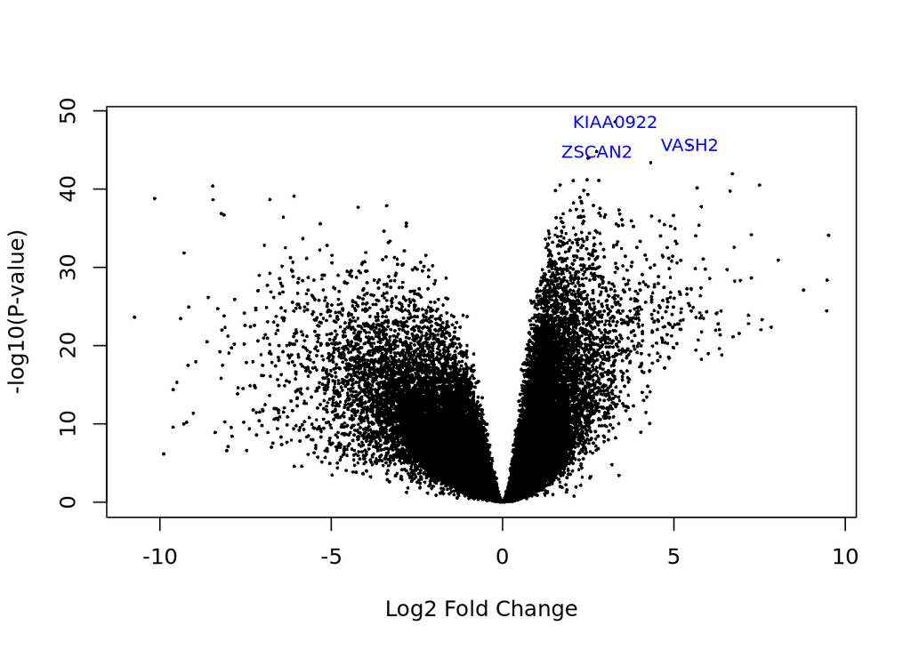

```r
volcanoplot(eb_results, coef = 2, highlight = 3, names = de_results$gene_name)
```

## Visualizando genes Differential expression

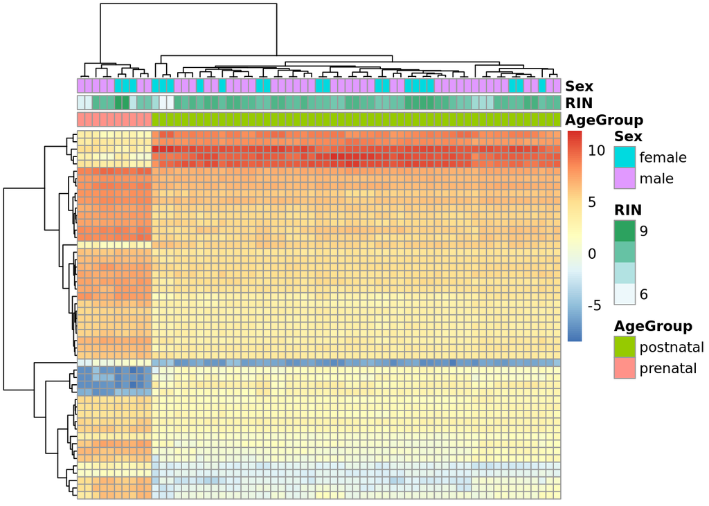

```r
## Extraer valores de los genes de interés
exprs_heatmap <- vGene$E[rank(de_results$adj.P.Val) <= 50, ]

## Creemos una tabla con información de las muestras
## y con nombres de columnas más amigables
df <- as.data.frame(colData(rse_gene_SRP045638)[, c("prenatal", "sra_attribute.RIN", "sra_attribute.sex")])
colnames(df) <- c("AgeGroup", "RIN", "Sex")

## Hagamos un heatmap
library("pheatmap")
pheatmap(
    exprs_heatmap,
    cluster_rows = TRUE,
    cluster_cols = TRUE,
    show_rownames = FALSE,
    show_colnames = FALSE,
    annotation_col = df
)
```

```r
## Para colores
library("RColorBrewer")

## Conviertiendo los grupos de edad a colores
col.group <- df$AgeGroup
levels(col.group) <- brewer.pal(nlevels(col.group), "Set1")
```

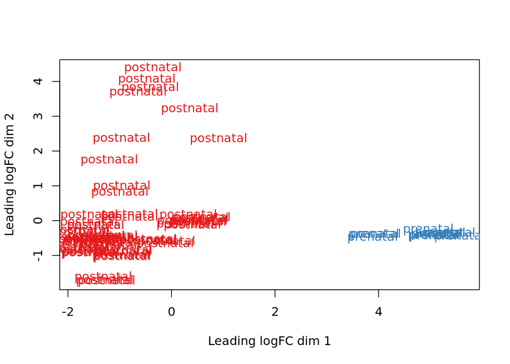

```r
col.group <- as.character(col.group)

## MDS por grupos de edad
plotMDS(vGene$E, labels = df$AgeGroup, col = col.group)
```

```r
## Conviertiendo los valores de Sex a colores
col.sex <- df$Sex
levels(col.sex) <- brewer.pal(nlevels(col.sex), "Dark2")
```

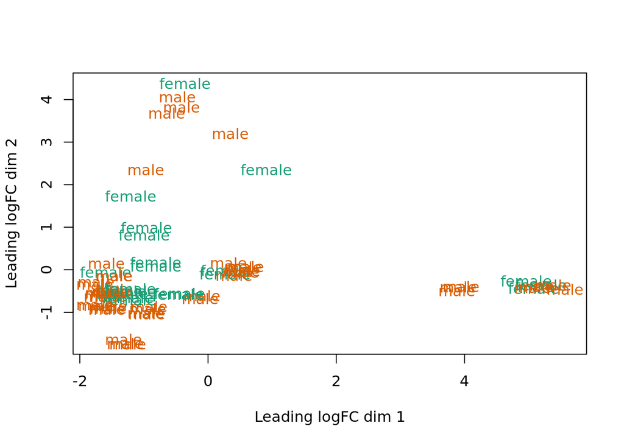

```r
col.sex <- as.character(col.sex)

## MDS por sexo
plotMDS(vGene$E, labels = df$Sex, col = col.sex)
```

## Ejercicio

```r
nombres_rse_gene <-rowRanges(rse_gene_SRP045638)$gene_name
id_rse_gene <- rowRanges(rse_gene_SRP045638)$gene_id

exprs_heatmap <- vGene$E[rank(de_results$adj.P.Val) <= 50, ]
posiciones <- match(rownames(exprs_heatmap),id_rse_gene)
# hacer un subconjunto de los ronames
filtered_id_names <-rowRanges(rse_gene_SRP045638)$gene_name[posiciones]

#remplazar los nombres de exprs_heatmap
head(exprs_heatmap)
```

```
##                    SRR2071341 SRR2071345 SRR2071346 SRR2071347 SRR2071348
## ENSG00000004487.15   5.692763   5.606393   5.430083  5.1569628   7.518297
## ENSG00000204178.9    4.811124   4.885577   4.990490  4.0719548   6.602715
## ENSG00000162419.12   3.293328   3.148314   3.171269  2.9890020   5.619231
## ENSG00000162415.6    3.160520   3.428597   3.237173  3.4659920   5.835181
## ENSG00000085552.16  -2.428045  -1.525600  -1.740955 -0.6997084   5.823926
## ENSG00000135829.16   6.919710   6.328120   6.620339  6.4279466   8.093594
##                    SRR2071349 SRR2071350 SRR2071351 SRR2071352 SRR2071353
## ENSG00000004487.15   7.445085   5.781973   5.448240   7.176618   5.556751
## ENSG00000204178.9    6.447543   4.980434   4.816663   6.493733   4.809241
## ENSG00000162419.12   5.374634   3.465953   3.094800   5.318709   3.279245
## ENSG00000162415.6    5.810944   3.306355   3.105620   5.483980   3.147572
## ENSG00000085552.16   5.898864  -1.623354  -1.685655   5.064748  -2.239830
## ENSG00000135829.16   8.091850   6.715528   6.727098   7.908553   6.404542
##                    SRR2071354 SRR2071355 SRR2071356 SRR2071357 SRR2071358
## ENSG00000004487.15   5.342522  5.6108146 5.40123972  5.6778968   5.595721
## ENSG00000204178.9    4.838252  4.9181433 4.97373564  4.9854609   4.864088
## ENSG00000162419.12   3.006375  3.7911593 3.64776299  3.5580599   3.256775
## ENSG00000162415.6    3.447960  3.6808560 3.07208609  3.5643530   3.094852
## ENSG00000085552.16  -1.171817  0.4056524 0.08769592  0.7091167  -2.021886
## ENSG00000135829.16   6.467804  6.5989476 6.41451229  6.6082238   6.720704
##                    SRR2071367 SRR2071368 SRR2071369 SRR2071370 SRR2071371
## ENSG00000004487.15  5.4210528   5.578470   5.741296   5.689600   5.745631
## ENSG00000204178.9   5.0068452   4.817734   4.934059   4.831015   5.006773
## ENSG00000162419.12  3.4922043   2.914296   3.416849   3.378930   3.133881
## ENSG00000162415.6   3.5083692   3.260165   3.342475   3.181437   3.326062
## ENSG00000085552.16 -0.7830737  -3.472285  -2.212114  -2.643438  -2.659916
## ENSG00000135829.16  6.7896782   6.507378   6.759352   6.599360   6.820730
##                    SRR2071376 SRR2071377 SRR2071378 SRR2071379 SRR1554533
## ENSG00000004487.15   5.635053   7.952253   7.475059   7.979059   5.541552
## ENSG00000204178.9    4.664567   6.490166   6.626266   6.593687   4.510478
## ENSG00000162419.12   3.413172   5.413163   5.449081   5.542702   3.054074
## ENSG00000162415.6    3.481478   5.588441   5.535767   5.914072   2.985952
## ENSG00000085552.16  -1.222757   6.764201   5.767626   6.716638  -2.673846
## ENSG00000135829.16   6.396282   8.357235   7.931288   8.160919   6.660800
##                    SRR1554534 SRR1554536 SRR1554537 SRR1554539 SRR1554540
## ENSG00000004487.15   5.635896   5.106621   7.462966   5.740171   5.459667
## ENSG00000204178.9    4.910449   4.104646   6.514863   4.958525   4.822441
## ENSG00000162419.12   3.230655   2.792566   5.561404   3.455911   3.086810
## ENSG00000162415.6    3.441184   3.419442   5.757972   3.292025   3.131839
```

[output cut: 36 more lines]

```
## ENSG00000135829.16   6.593186   6.434286   8.399187   8.099988   6.567280
##                    SRR2071360 SRR2071361 SRR2071362 SRR2071363 SRR2071364
## ENSG00000004487.15  5.7774767   5.612471  5.6127030   5.765383  5.9287563
## ENSG00000204178.9   4.8690042   4.912722  5.0396130   4.945136  5.2379472
## ENSG00000162419.12  3.5694797   3.321766  3.4993089   3.775119  3.6102983
## ENSG00000162415.6   3.7662727   3.123410  3.6440209   3.590357  3.5663103
## ENSG00000085552.16  0.3482328  -3.638879  0.1027569  -1.112902  0.9033453
## ENSG00000135829.16  6.6005127   6.545583  6.5050058   6.579403  6.5488977
##                    SRR2071365 SRR2071372 SRR2071373 SRR2071374 SRR2071375
## ENSG00000004487.15   5.749363   5.764838   5.449514   5.149179   5.599198
## ENSG00000204178.9    5.086634   4.882813   4.728208   4.940981   4.844950
## ENSG00000162419.12   3.236050   3.202146   3.350502   3.325939   3.523342
## ENSG00000162415.6    3.623968   3.348796   2.738244   2.959642   3.451274
## ENSG00000085552.16  -1.264866  -1.098176  -1.817679  -1.027819  -1.250846
## ENSG00000135829.16   6.616591   6.340054   6.493427   6.410397   6.550054
```

```r
exprs_heatmap
```

[output not shown]

[output cut: 608 more lines]

```
## ENSG00000121210.15  2.9181583  2.5220934  1.8633299  2.3270241  2.3736446
## ENSG00000070808.15  9.7565595 11.3068721 10.7575619 10.1638385 10.2228134
## ENSG00000280776.1   0.8439706  1.7091790  2.5383420  2.3697737  1.5935029
## ENSG00000112182.14  4.4614285  2.9614974  2.4236303  3.0438912  3.1035033
## ENSG00000196591.11  6.0401408  5.0272026  5.5607569  5.8703525  5.7267806
## ENSG00000197442.9   5.2171443  5.3661214  5.6263453  5.4726402  5.8188273
## ENSG00000158321.15  6.0458486  5.5280264  4.5738912  4.7250123  5.5545557
## ENSG00000213420.7   0.9122189  0.7476531  0.8971635  0.9441670  1.7546082
## ENSG00000147535.16  3.5751839  3.7435796  3.6144086  3.9263776  4.1487392
## ENSG00000137571.10  1.6774735  0.3788712  0.6699860  0.6151494  1.0356765
## ENSG00000196150.13  3.7059053  3.2178915  3.1605959  3.3150424  3.1986151
## ENSG00000171843.15  5.2995395  4.4005924  4.4360140  4.5210921  4.4267133
## ENSG00000137142.4   1.9705411 -0.5797089  0.2881153 -1.0729066  0.3046725
## ENSG00000147140.15  6.9064789  6.7488391  6.7914191  6.4708004  6.7753838
## ENSG00000147274.14  6.4464029  5.6863705  5.9860307  6.3374270  6.3840198
```

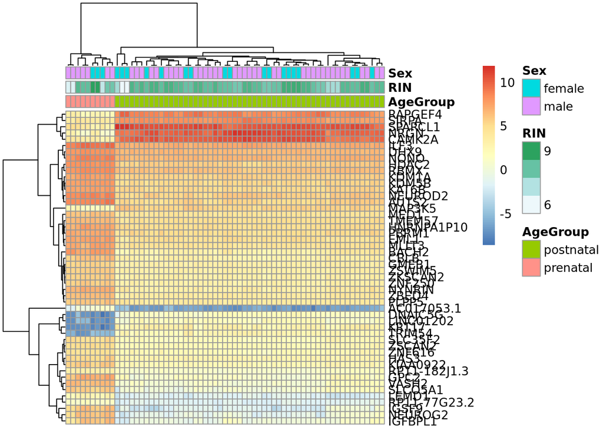

```r
row.names(exprs_heatmap) <- filtered_id_names

pheatmap(
    exprs_heatmap,
    #que agrupe los genes tanto en renglones como en cols que son las muestras
    cluster_rows = TRUE,
    cluster_cols = TRUE,
    show_rownames = TRUE,
    show_colnames = FALSE,
    annotation_col = df
)
```

```r
# default value of pdf is 4
pdf("EJERCICIOS/pheatmap_con_nombres.pdf", height=14, useDingbats = FALSE)
## Y luego podemos cambiar el valor de show_rownames de FALSE a TRUE
pheatmap(
    exprs_heatmap,
    #que agrupe los genes tanto en renglones como en cols que son las muestras
    cluster_rows = TRUE,
    cluster_cols = TRUE,
    show_rownames = TRUE,
    show_colnames = FALSE,
    annotation_col = df
)
dev.off()
```

```r
# Resultado en carpeta EJERCICIOS
```

# Clase viernes 26 de febrero

Ejercicio de revisión.

```r
speaqeasy_data <- file.path(tempdir(), "rse_speaqeasy.RData")
download.file("https://github.com/LieberInstitute/SPEAQeasy-example/blob/master/rse_speaqeasy.RData?raw=true", speaqeasy_data, mode = "wb")
load(speaqeasy_data, verbose = TRUE)
```

```
## Loading objects:
##   rse_gene
```

- ¿Hay diferencias en totalAssignedGene o mitoRate entre los grupos de diagnosis (PrimaryDx)?

*Nota:* FullRank significa que todas las columnas son linealmente independientes.

```r
## Eliminemos el diagnosis "Other" porque no tiene información
rse_gene$PrimaryDx <- droplevels(rse_gene$PrimaryDx)
table(rse_gene$PrimaryDx)
```

```
##
## Bipolar Control
##      20      20
```

```r
## Exploremos numéricamente diferencias entre grupos de diagnosis para
## varias variables
with(colData(rse_gene), tapply(totalAssignedGene, PrimaryDx, summary))
```

```
## $Bipolar
##    Min. 1st Qu.  Median    Mean 3rd Qu.    Max.
## 0.09529 0.24454 0.29773 0.28867 0.34662 0.38358
##
## $Control
##    Min. 1st Qu.  Median    Mean 3rd Qu.    Max.
##  0.1384  0.2575  0.2895  0.2984  0.3537  0.4073
```

```r
with(colData(rse_gene), tapply(mitoRate, PrimaryDx, summary))
```

```
## $Bipolar
##    Min. 1st Qu.  Median    Mean 3rd Qu.    Max.
## 0.01297 0.01555 0.01735 0.01818 0.01980 0.03019
##
## $Control
##    Min. 1st Qu.  Median    Mean 3rd Qu.    Max.
## 0.01194 0.01564 0.01911 0.02029 0.02439 0.03037
```

```r
## Podemos resolver la primeras preguntas con iSEE
if (interactive()) iSEE::iSEE(rse_gene)
```

Gráfica respuesta con iSEE en carpeta EJERCICIOS/ColumnDataPlot1.pdf

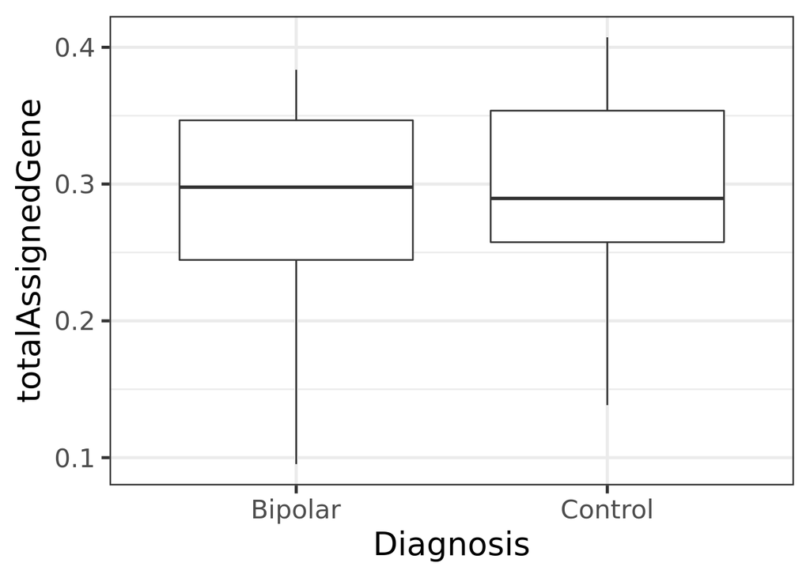

```r
## O hacer graficas nosotros mismos. Aquí les muestro una posible respuesta
## con ggplot2
library("ggplot2")
ggplot(
    as.data.frame(colData(rse_gene)),
    aes(y = totalAssignedGene, group = PrimaryDx, x = PrimaryDx)
) +
    geom_boxplot() +
    theme_bw(base_size = 20) +
    xlab("Diagnosis")
```

- Grafica la expresión de SNAP25 para cada grupo de diagnosis.

```r
## En este objeto los nombres de los genes vienen en la variable "Symbol"
i <- which(rowRanges(rse_gene)$Symbol == "SNAP25")
i
```

```
## [1] 54098
```

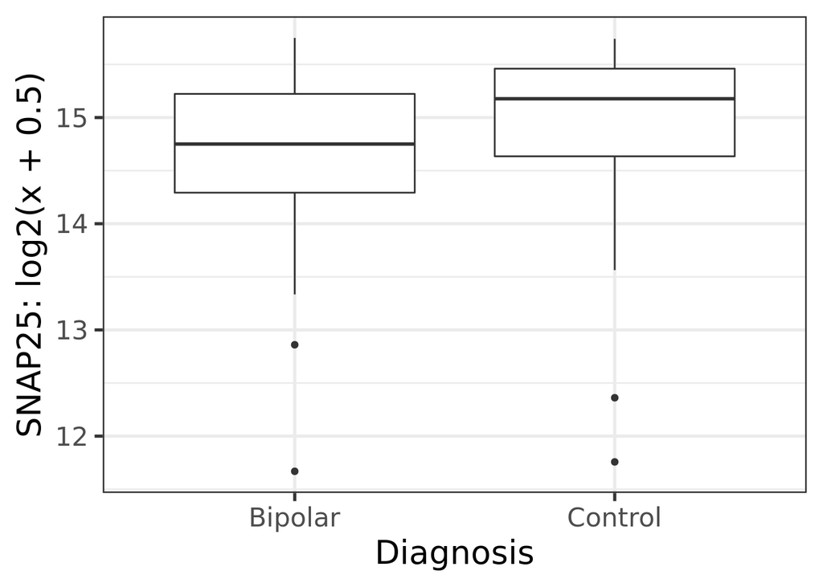

```r
## Para graficar con ggplot2, hagamos un pequeño data.frame
df <- data.frame(
    expression = assay(rse_gene)[i, ],
    Dx = rse_gene$PrimaryDx
)

## Ya teniendo el pequeño data.frame, podemos hacer la gráfica
ggplot(df, aes(y = log2(expression + 0.5), group = Dx, x = Dx)) +
    geom_boxplot() +
    theme_bw(base_size = 20) +
    xlab("Diagnosis") +
    ylab("SNAP25: log2(x + 0.5)")
```

Gráfica hecha con iSEE para el gen SNAP25 se ecnuentra en carpeta EJERCICIOS/FeatureAssayPlot1SNAP25.pdf

- Sugiere un modelo estadistico que podríamos usar en una análisis de expresión diferencial. Verifica que si sea un modelo full rank. ¿Cúal sería el o los coeficientes de interés?

```r
## Para el model estadístico exploremos la información de las muestras
colnames(colData(rse_gene))
```

```
##  [1] "SAMPLE_ID"                          "FQCbasicStats"
##  [3] "perBaseQual"                        "perTileQual"
##  [5] "perSeqQual"                         "perBaseContent"
##  [7] "GCcontent"                          "Ncontent"
##  [9] "SeqLengthDist"                      "SeqDuplication"
## [11] "OverrepSeqs"                        "AdapterContent"
## [13] "KmerContent"                        "SeqLength_R1"
## [15] "percentGC_R1"                       "phred20-21_R1"
## [17] "phred48-49_R1"                      "phred76-77_R1"
## [19] "phred100-101_R1"                    "phredGT30_R1"
## [21] "phredGT35_R1"                       "Adapter50-51_R1"
## [23] "Adapter70-71_R1"                    "Adapter90_R1"
## [25] "SeqLength_R2"                       "percentGC_R2"
## [27] "phred20-21_R2"                      "phred48-49_R2"
## [29] "phred76-77_R2"                      "phred100-101_R2"
```

[output cut: 19 more lines]

```r
## Ojo! Acá es importante que hayamos usado droplevels(rse_gene$PrimaryDx)
## si no, vamos a tener un modelo que no sea _full rank_
mod <- with(
    colData(rse_gene),
    model.matrix(~ PrimaryDx + totalAssignedGene + mitoRate + rRNA_rate + BrainRegion + Sex + AgeDeath)
)

## Exploremos el modelo de forma interactiva
if (interactive()) {
    ## Tenemos que eliminar columnas que tienen NAs.
    info_no_NAs <- colData(rse_gene)[, c(
        "PrimaryDx", "totalAssignedGene", "rRNA_rate", "BrainRegion", "Sex",
        "AgeDeath", "mitoRate", "Race"
    )]
    ExploreModelMatrix::ExploreModelMatrix(
        info_no_NAs,
        ~ PrimaryDx + totalAssignedGene + mitoRate + rRNA_rate + BrainRegion + Sex + AgeDeath
    )

    ## Veamos un modelo más sencillo sin las variables numéricas (continuas) porque
    ## ExploreModelMatrix nos las muestra como si fueran factors (categoricas)
    ## en vez de continuas
    ExploreModelMatrix::ExploreModelMatrix(
        info_no_NAs,
        ~ PrimaryDx + BrainRegion + Sex
    )

    ## Si agregamos + Race nos da errores porque Race solo tiene 1 opción
    # ExploreModelMatrix::ExploreModelMatrix(
    #     info_no_NAs,
    #     ~ PrimaryDx + BrainRegion + Sex + Race
    # )
}
```